# BIOL343 Coding Challenge 4

Group 6 — names and student numbers in the chunk below

09 October 2026

# BIOL343 Coding Challenge 4

## Group Members

```r
# Name - Queen's Student Number

# 1. Margo Kaminska - 20449041

# 2. Allie Goodyear - 20443234

# 3. Emma Popple - 20467453

# 4. Téa Hope - 20459579

# 5. Grant Bishop - 20485713
```

# DO THIS FIRST

Copy and paste this into your R Console to start positpal, but replace `FILENAME.Rmd` with the name you are going to use for the .R or .Rmd file you are going to upload (rename the template first, e.g. `Group_#_CC4.Rmd`, and use that exact name). **Do not include it as a code chunk.**

```
install.packages("remotes")
remotes::install_url("https://quantitative.bio/downloads/positpal.tar.gz", upgrade = "never")
positpal::start("FILENAME.Rmd")
```

Before you run it: create or open an R project folder so that it is your working directory, then save this file in that folder under the name you will upload, and check that autosave is on (*File → Auto Save*). See OnQ and use the positpal chatbot if you are having trouble with positpal.

# Part 1 — Import and inspect

The data file is `data/AbroniaFloralData.csv`: one row per plant, from 12 coastal sites, with the mating system of the site (`self_inc`: SI or SC), the site’s latitude, and four floral traits. The instructions describe the study and the two hypotheses. **Do not edit the file by hand.**

## 1. Import the data

Import the observations and save it as an object called `floral_data`.

```r
floral_data <- read.csv("data/AbroniaFloralData.csv")
```

## 2. Inspect the data

Check the object with `dim()`, `head()`, `str()` and `summary()`. Look for the usual problems: columns of the wrong type, and missing values.

```r
dim(floral_data)
```

```
## [1] 966   8
```

```r
head(floral_data)
```

```
##   self_inc site latitude_N     plant_id umbel_angle_deg flower_number face_diam_mm tube_length_mm
## 1       SI CMGA   34.22204  CMGA.2010.1             140            18        11.24         13.080
## 2       SI CMGA   34.22204 CMGA.2010.10              90             8        10.51         12.315
## 3       SI CMGA   34.22204 CMGA.2010.11             120            18        11.14         13.880
## 4       SI CMGA   34.22204 CMGA.2010.12             180            22        10.49         15.585
## 5       SI CMGA   34.22204 CMGA.2010.13             130            21        10.76         14.615
## 6       SI CMGA   34.22204 CMGA.2010.14              95            11        11.02         15.965
```

```r
str(floral_data)
```

```
## 'data.frame':    966 obs. of  8 variables:
##  $ self_inc       : chr  "SI" "SI" "SI" "SI" ...
##  $ site           : chr  "CMGA" "CMGA" "CMGA" "CMGA" ...
##  $ latitude_N     : num  34.2 34.2 34.2 34.2 34.2 ...
##  $ plant_id       : chr  "CMGA.2010.1" "CMGA.2010.10" "CMGA.2010.11" "CMGA.2010.12" ...
##  $ umbel_angle_deg: int  140 90 120 180 130 95 105 130 110 115 ...
##  $ flower_number  : int  18 8 18 22 21 11 10 16 14 12 ...
##  $ face_diam_mm   : num  11.2 10.5 11.1 10.5 10.8 ...
##  $ tube_length_mm : num  13.1 12.3 13.9 15.6 14.6 ...
```

```r
summary(floral_data)
```

```
##       self_inc          site       latitude_N         plant_id   umbel_angle_deg flower_number
##  Length   :966   Length   :966   Min.   :34.22   Length   :966   Min.   : 30.0   Min.   : 6.00
##  N.unique :  2   N.unique : 12   1st Qu.:34.41   N.unique :966   1st Qu.:100.0   1st Qu.:13.00
##  N.blank  :  0   N.blank  :  0   Median :35.30   N.blank  :  0   Median :110.0   Median :15.00
##  Min.nchar:  2   Min.nchar:  4   Mean   :36.21   Min.nchar: 11   Mean   :111.9   Mean   :15.44
##  Max.nchar:  2   Max.nchar:  5   3rd Qu.:36.95   Max.nchar: 13   3rd Qu.:125.0   3rd Qu.:17.00
##                                  Max.   :41.44                   Max.   :225.0   Max.   :28.00
##                                                                  NAs    :5
##   face_diam_mm    tube_length_mm
##  Min.   : 4.156   Min.   : 4.357
##  1st Qu.: 8.835   1st Qu.:11.992
##  Median :10.501   Median :13.096
##  Mean   :10.069   Mean   :12.628
##  3rd Qu.:11.499   3rd Qu.:14.172
##  Max.   :15.084   Max.   :19.100
##
```

**Question 1:** In statistical terms, what is the **statistical population** in this study, and what is the **sample**? Give one reason the sample might not be a random, unbiased sample of that population.

**Answer:** The statistical population is all *Abronia umbellata* plants across the species’ geographic range along the Pacific coast. The sample is the plants measured at the 12 study sites, from just north of Los Angeles, California, to southern Oregon. One reason the sample might not be completely random or unbiased is that plants were only sampled from 12 selected sites, so plants from other locations or habitats may not be represented.

# Part 2 — Distributions

## 3. Plot frequency distributions

Plot the distributions of `face_diam_mm`, with facets so that SI and SC plants are in separate panels. Choose an appropriate `binwidth` that shows the shape of the data distribution, add axis labels with units and a title, and use a ‘clean’ theme suitable for publication. Then do the same for `flower_number`, with `binwidth = 1`. If R prints a message about `bins = 30`, you have not set the binwidth; the chunk option `message=FALSE` (already set on these chunks) hides messages like that in the knitted file.

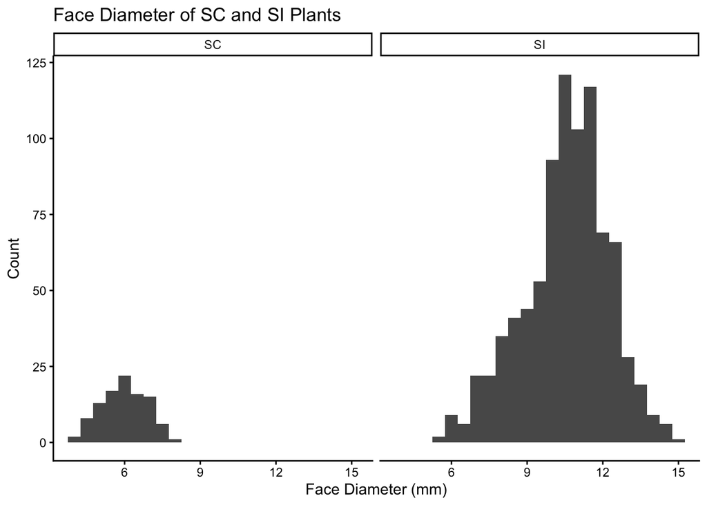

```r
library(ggplot2)
ggplot(aes(x=face_diam_mm), data=floral_data) +
    geom_histogram(binwidth=0.5) +
    facet_wrap(~self_inc) +
    labs(
        title = "Face Diameter of SC and SI Plants",
        x = "Face Diameter (mm)",
        y = "Count"
    ) +
    theme_classic()
```

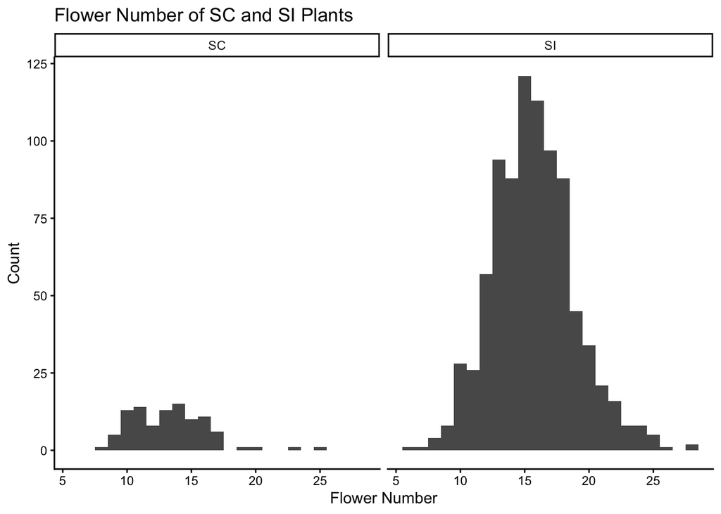

```r
ggplot(aes(x=flower_number), data=floral_data) +
    geom_histogram(binwidth=1) +
    facet_wrap(~self_inc) +
    labs(
        title = "Flower Number of SC and SI Plants",
        x = "Flower Number",
        y = "Count"
    ) +
    theme_classic()
```

**Question 2:** Of the three common population distributions (Gaussian, Poisson, binomial), which one is the best model for `face_diam_mm`, and which for `flower_number`? Explain with respect to the *type* of data as well as the shape of the histogram.

**Answer:** For `face_diam_mm` a Gaussian distribution would be the best model because face diameter is continuous quantitative data that is measured in millimetres and can take decimal values. Its histogram would ideally be approximately bell-shaped and symmetric, which is characteristic of a Gaussian distribution. For `flower_number` a Poisson distribution would be the best model because flower number is discrete count data, it represents the number of flowers in an inflorescence and can only take whole-number values. Its histogram may be right-skewed, with many smaller counts and fewer larger counts, which is characteristic of a Poisson distribution.

## 4. Mean, standard deviation and coefficient of variation

Make two vectors, `SI` and `SC`, containing the face diameters of the SI plants and of the SC plants. For **each** vector, calculate the sample size, the mean, the standard deviation, and the coefficient of variation.

```r
SI <- floral_data$face_diam_mm[floral_data$self_inc == "SI"]
SI <- SI[!is.na(SI)]

SC <- floral_data$face_diam_mm[floral_data$self_inc == "SC"]
SC <- SC[!is.na(SC)]

# SI plants
length(SI)
```

```
## [1] 866
```

```r
mean(SI)
```

```
## [1] 10.54396
```

```r
sd(SI)
```

```
## [1] 1.693516
```

```r
sd(SI) / mean(SI) * 100
```

```
## [1] 16.06148
```

```r
# SC plants
length(SC)
```

```
## [1] 100
```

```r
mean(SC)
```

```
## [1] 5.960045
```

```r
sd(SC)
```

```
## [1] 0.8930541
```

```r
sd(SC) / mean(SC) * 100
```

```
## [1] 14.98402
```

**Question 3:** The two standard deviations are very different, but the two coefficients of variation are almost the same. What does that tell you about how variation in flower size relates to mean flower size?

**Answer:** The similar coefficients of variation indicate that variation in flower size is proportional to mean flower size. Although the standard deviations differ, both groups have a similar amount of variation relative to their mean, suggesting that flowers with a larger mean size also tend to have a proportionally larger spread in size.

## 5. Trait means by mating system and by site

Report the sample size and the mean of each of the four traits for SI and for SC plants, using `dplyr` commands. One trait has missing values, so the code must handle `NA`.

```r
floral_data %>%
  group_by(self_inc) %>%
  summarise(
    n = n(),
    mean_umbel_angle_deg = mean(umbel_angle_deg, na.rm = TRUE),
    mean_flower_number = mean(flower_number, na.rm = TRUE),
    mean_face_diam_mm = mean(face_diam_mm, na.rm = TRUE),
    mean_tube_length_mm = mean(tube_length_mm, na.rm = TRUE)
  )
```

```
## # A tibble: 2 × 6
##   self_inc     n mean_umbel_angle_deg mean_flower_number mean_face_diam_mm mean_tube_length_mm
##   <chr>    <int>                <dbl>              <dbl>             <dbl>               <dbl>
## 1 SC         100                 88.3               13.3              5.96                6.21
## 2 SI         866                115.                15.7             10.5                13.4
```

Now make a second summary with one row per site: the site’s mating system, its latitude, the number of plants and the mean face diameter. Then plot mean face diameter (y) against latitude (x), one point per site, coloured by mating system, with axis labels with units, a legend title and a clean theme.

```r
site_summary <- floral_data %>%
  group_by(site) %>%
  summarise(
    mating_system = first(self_inc),
    latitude_N = first(latitude_N),
    n = n(),
    mean_face_diam_mm = mean(face_diam_mm, na.rm = TRUE)
  )
site_summary
```

```
## # A tibble: 12 × 5
##    site  mating_system latitude_N     n mean_face_diam_mm
##    <chr> <chr>              <dbl> <int>             <dbl>
##  1 CBVA  SI                  34.3    65             10.7
##  2 CCOA  SI                  34.4    90             11.2
##  3 CFAA  SC                  40.8    30              6.69
##  4 CGBA  SC                  41.4    35              5.71
##  5 CGN2A SI                  35.0    85              8.75
##  6 CGNA  SI                  35.0    60              7.59
##  7 CMGA  SI                  34.2    91             10.8
##  8 CMNA  SI                  36.9   130             11.5
##  9 COSA  SC                  41.4    35              5.59
## 10 CSEA  SI                  37.0    95             11.4
## 11 CSPA  SI                  35.3   125              9.85
## 12 CWRA  SI                  37.0   125             11.5
```

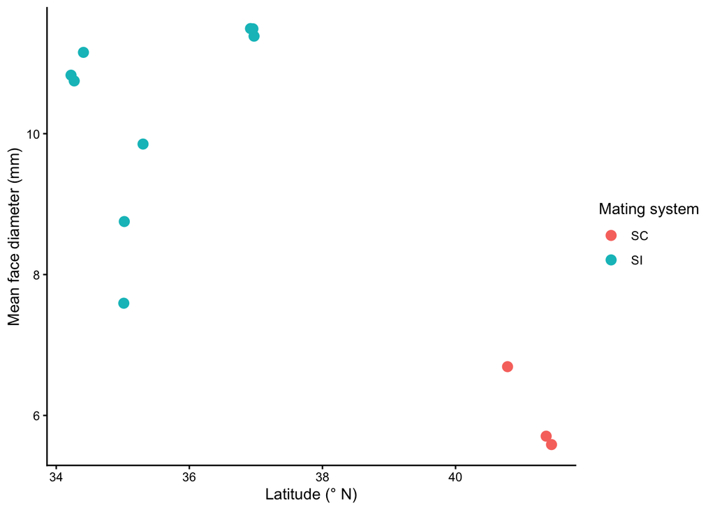

```r
ggplot(site_summary, aes(
    x = latitude_N,
    y = mean_face_diam_mm,
    colour = mating_system
)) +
    geom_point(size = 3) +
  labs(
    x = "Latitude (° N)",
    y = "Mean face diameter (mm)",
    colour = "Mating system"
  ) +
  theme_classic()
```

**Question 4:** Do the four traits differ between SI and SC plants in the direction predicted by the second hypothesis in the instructions? Which trait shows the largest relative difference?

**Answer:** All four traits differ between SI and SC plants in the direction predicted by the second hypothesis. SC plants have smaller mean umbel angles (88.3° vs. 115°), fewer flowers (13.3 vs. 15.7), smaller face diameters (5.96 mm vs. 10.5 mm), and shorter tube lengths (6.21 mm vs. 13.4 mm) than SI plants. Tube length shows the largest relative difference, with SC plants having a mean tube length approximately 53.7% smaller than SI plants. Face diameter is the second-largest difference, at approximately 43.2% smaller.

# Part 3 — From the sample to the population

## 6. Standard error and confidence interval

For `SI` and for `SC`, calculate the standard error of the mean and the 95% confidence interval **from the equations**: $SE = s / \sqrt{n}$ and $CI = \bar x \pm 1.96 \times SE$. Print both intervals.

```r
# SI plants
SI <- floral_data$face_diam_mm[floral_data$self_inc == "SI"]
SI <- SI[!is.na(SI)]

N <- length(SI)
x <- mean(SI)
sd <- sd(SI)
se <- sd/sqrt(N)
CI <- c(x - 1.96*se, x + 1.96*se)

print(se)
```

```
## [1] 0.05754802
```

```r
print(CI)
```

```
## [1] 10.43116 10.65675
```

```r
print(CI[2] - CI[1])
```

```
## [1] 0.2255883
```

```r
# SC plants
SC <- floral_data$face_diam_mm[floral_data$self_inc == "SC"]
SC <- SC[!is.na(SC)]

N <- length(SC)
x <- mean(SC)
sd <- sd(SC)
se <- sd/sqrt(N)
CI <- c(x - 1.96*se, x + 1.96*se)

print(se)
```

```
## [1] 0.08930541
```

```r
print(CI)
```

```
## [1] 5.785006 6.135084
```

```r
print(CI[2] - CI[1])
```

```
## [1] 0.3500772
```

**Question 5:** What does each confidence interval represent? Do the two intervals overlap, and what does that suggest about the two populations?

**Answer:** Each 95% confidence interval estimates the range of plausible values for the true mean face diameter of the SI or SC population. If we repeatedly took random samples and calculated confidence intervals in the same way, approximately 95% of those intervals would contain their population’s true mean. The two confidence intervals do not overlap, suggesting that the mean face diameters of SI and SC plants differ substantially, with SC plants having smaller flowers on average. This supports the hypothesis that self-compatible plants invest less in floral traits that attract pollinators.

## 7. The central limit theorem

Set the seed with `set.seed(343)`. Use `sample()` to draw a random sub-sample of 10 plants from `SI`, then one of 100, then one of 500. For each sub-sample report the mean, the standard deviation and the width of the 95% confidence interval (upper limit minus lower limit), and compare them with the values for all 866 SI plants from Sections 4 and 6.

```r
set.seed(343)

# Random subsamples of SI plants
SI_10 <- sample(SI, size = 10)
SI_100 <- sample(SI, size = 100)
SI_500 <- sample(SI, size = 500)

# Sample of 10 plants
x <- mean(SI_10)
s <- sd(SI_10)
se <- s / sqrt(10)
CI <- c(x - 1.96*se, x + 1.96*se)
print(x)
```

```
## [1] 10.48767
```

```r
print(s)
```

```
## [1] 1.905873
```

```r
print(CI[2] - CI[1])
```

```
## [1] 2.362545
```

```r
# Sample of 100 plants
x <- mean(SI_100)
s <- sd(SI_100)
se <- s / sqrt(100)
CI <- c(x - 1.96*se, x + 1.96*se)
print(x)
```

```
## [1] 10.34448
```

```r
print(s)
```

```
## [1] 1.739815
```

```r
print(CI[2] - CI[1])
```

```
## [1] 0.6820074
```

```r
# Sample of 500 plants
x <- mean(SI_500)
s <- sd(SI_500)
se <- s / sqrt(500)
CI <- c(x - 1.96*se, x + 1.96*se)
print(x)
```

```
## [1] 10.58424
```

```r
print(s)
```

```
## [1] 1.675787
```

```r
print(CI[2] - CI[1])
```

```
## [1] 0.2937784
```

```r
# All 866 SI plants
x <- mean(SI)
s <- sd(SI)
se <- s / sqrt(866)
CI <- c(x - 1.96*se, x + 1.96*se)
print(x)
```

```
## [1] 10.54396
```

```r
print(s)
```

```
## [1] 1.693516
```

```r
print(CI[2] - CI[1])
```

```
## [1] 0.2255883
```

# Part 4 — Probability and tests

## 8. Z-scores and probability

Convert `SI` to z-scores and plot a histogram of them. Then convert the **mean of the SC plants** to a z-score relative to the SI sample (subtract the SI mean, divide by the SI standard deviation), and use `pnorm()` to calculate the probability of drawing a plant with a face diameter that small **or smaller** from the SI population.

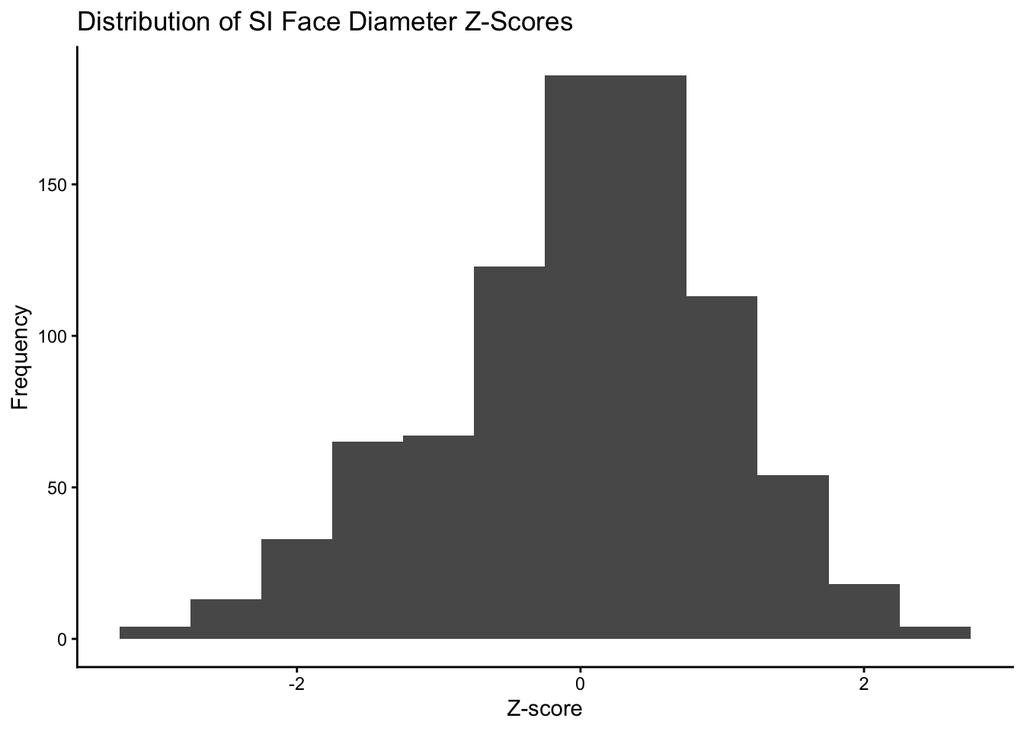

```r
# Convert SI measurements to z-scores
SI_z <- (SI - mean(SI)) / sd(SI)

#make a histogram
ggplot(data.frame(SI_z), aes(x = SI_z)) +
  geom_histogram(binwidth = 0.5) +
  labs(
    title = "Distribution of SI Face Diameter Z-Scores",
    x = "Z-score",
    y = "Frequency"
  ) +
  theme_classic()
```

```r
# Calculate the mean of SC plants
SC_mean <- mean(SC)

# Calculate the z-score of the SC mean relative to SI
SC_mean_z <- (SC_mean - mean(SI)) / sd(SI)

# Calculate the probability of drawing a plant this small or smaller
pnorm(SC_mean_z)
```

```
## [1] 0.003397337
```

**Question 7:** Is this a one-tailed or a two-tailed question, and why? What does the probability say about whether SC flowers are simply small SI flowers?

**Answer:** This is a one-tailed quesiton, since we are calculating the probability of finding a plant with a face diameter equal to the mean of SC plants or smaller using `pnorm()`. The probability tells us the probability of a face diameter at or below the SC mean under the SI distribution. If the probability is very low, it suggests that SC flowers are unusually small compared to the SI population, providing evidence that they may not simply be smaller individuals from the same population.

## 9. Two-sample *t*-test

Test whether SI and SC plants differ in face diameter with a t-test. Report *t*, the degrees of freedom, the p-value and the 95% confidence interval of the difference. Then calculate *t* yourself from the two-sample equation, $t = (\bar x - \bar y) / \sqrt{SE_x^2 + SE_y^2}$, using the standard errors from Section 6, and check that it matches.

```r
#two sample t-test
t.test(SI, SC)
```

```
##
##  Welch Two Sample t-test
##
## data:  SI and SC
## t = 43.146, df = 194.45, p-value < 2.2e-16
## alternative hypothesis: true difference in means is not equal to 0
## 95 percent confidence interval:
##  4.374381 4.793447
## sample estimates:
## mean of x mean of y
## 10.543959  5.960045
```

```r
#calculate the means
mean_SI <- mean(SI, na.rm = TRUE)
mean_SC <- mean(SC, na.rm = TRUE)

# Calculate the standard errors (Section 6)
SE_SI <- sd(SI, na.rm = TRUE) / sqrt(sum(!is.na(SI)))
SE_SC <- sd(SC, na.rm = TRUE) / sqrt(sum(!is.na(SC)))

#calculate t manually
t_manual <- (mean_SI - mean_SC) / sqrt(SE_SI^2+ SE_SC^2)
t_manual
```

```
## [1] 43.14622
```

**Question 8:** Every statistical test has assumptions. Name two assumptions of the *t*-test and say, in one sentence each, whether you think the *Abronia* data meet them.

**Answer:** Two assumptions of the t-test are approximate normality and independence of observations. The histograms can be used to assess whether face diameter is approximately normally distributed within each mating system, although they cannot prove normality. The plants were randomly sampled at the study sites, which supports independence, but plants from the same site could be more similar to one another, potentially affecting this assumption.

## 10. Face diameter against tube length

Plot `tube_length_mm` (y) against `face_diam_mm` (x), coloured by `self_inc`, with axis labels with units, a legend title, and a clean theme. Give the figure a caption with the chunk option `fig.cap = "..."`, and hide the code with `echo = FALSE` so that only the figure and its caption appear in the knitted document.

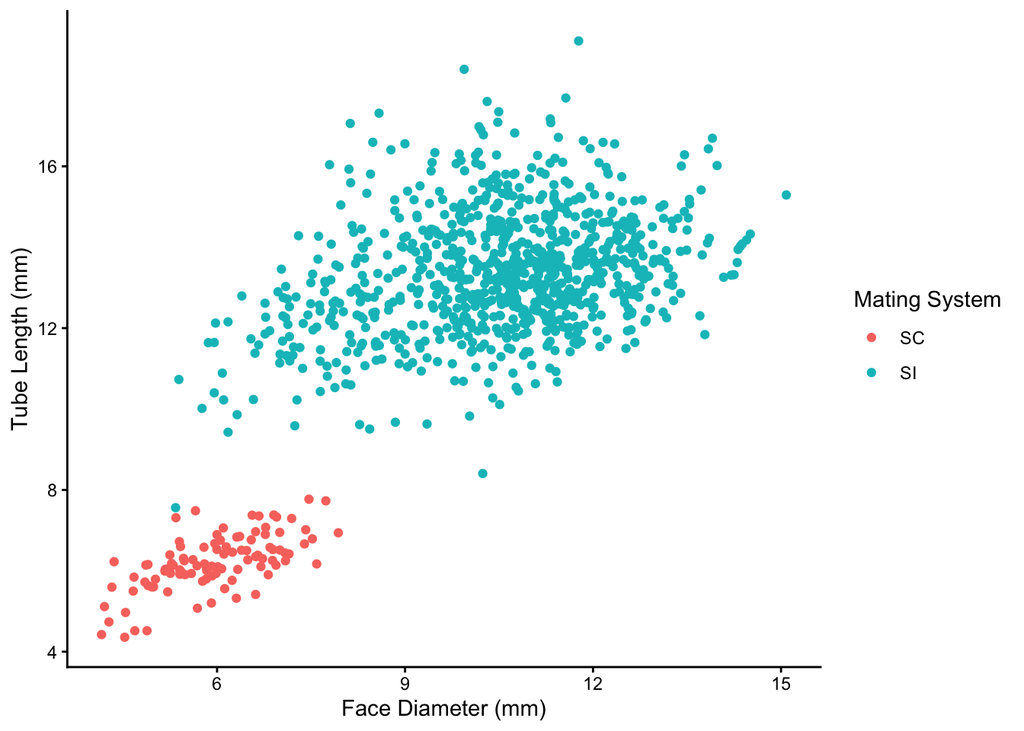

Relationship between flower face diameter (mm) and tube length (mm) in self-incompatible (SI) and self-compatible (SC) Abronia umbellata plants.

**Question 9:** Using everything above — the site plot in Section 5, the trait means, the *t*-test and this figure — what do the data say about the two hypotheses in the instructions? Answer in a short paragraph.

**Answer:** The data provide support for both hypotheses. The site plotshows that self-compatible (SC) populations occur at higher lattitudes than most self-incompatible populations, consistent with the hypothesis that SC evolves near geographic range limits where mates or pollinators may be less available. The trait means show that SC plants have smaller umbel angles, fewer flowers, smaller face diameters, and shorter tubes than SI plants. The t-test can determine whether the difference in face diameter is statistically significant, while the face diameter versus tube length plot illustrates the relationship between these floral traits and mating system. Overall, these patterns support the hypothesis that SC plants invest less in floral traits that attract pollinators, although the observational data do not establish causation.

# DO THIS LAST

When your document is finished, knit it, open the `.html` in a web browser and **print it to PDF** (*File → Print → Save as PDF*; name it `Group_#_CC4.pdf`). Then copy and paste this into the R Console to stop positpal and create your coding log. **Do not include it as a code chunk.**

```
positpal::stop_capture()
positpal::export_capture()
```

`export_capture()` prints the name and location of the `my-capture-YYYYMMDD-HHMMSS.zip` it creates beside this file. **Each group member** uploads their own `.zip` to the **“CC4 — Coding Log (individual)”** dropbox on OnQ; the group’s `.Rmd` and the **`.pdf`** (not the `.html` — OnQ shows uploaded HTML as source code, not as a page) go to your section’s **TUT02-CC4** or **TUT03-CC4** folder. Submissions without the log are incomplete. If `export_capture()` fails, zip the `.capture` folder yourself and upload that instead.